# Project (Productivity) With Random Selection

2022-12-04

# Intro to data set

Source: https://www.kaggle.com/datasets/ishadss/productivity-prediction-of-garment-employees

Variables:

01 date : Date in MM-DD-YYYY

02 day : Day of the Week

03 quarter : A portion of the month. A month was divided into four quarters

04 department : Associated department with the instance

05 teamno : Associated team number with the instance

06 noofworkers : Number of workers in each team

07 noofstylechange : Number of changes in the style of a particular product

08 targetedproductivity : Targeted productivity set by the Authority for each team for each day.

09 smv : Standard Minute Value, it is the allocated time for a task

10 wip : Work in progress. Includes the number of unfinished items for products

11 overtime : Represents the amount of overtime by each team in minutes

12 incentive : Represents the amount of financial incentive (in BDT) that enables or motivates a particular course of action.

13 idletime : The amount of time when the production was interrupted due to several reasons

14 idlemen : The number of workers who were idle due to production interruption

15 actual_productivity : The actual % of productivity that was delivered by the workers. It ranges from 0-1.

# Some Questions.

1. Which department is most productive?
2. Which day of the week is most productive for each department?
3. Which team in the sewing department is the most productive?
4. Does the amount of over time impact the productivity in the sewing department?
5. Does the amount of incentives impact the productivity in the sewing department?
6. Does the number of workers impact the productivity in the sewing department?

# Data cleaning

### 1. Read in the data set. Check if it’s a tibble.

```r
library(readr)
work <- read_csv("~/Desktop/STAT510_F22/datasets/garments_worker_productivity.csv")
head(work)
```

```
## # A tibble: 6 × 15
##   date   quarter depar…¹ day    team targe…²   smv   wip over_…³ incen…⁴ idle_…⁵
##   <chr>  <chr>   <chr>   <chr> <dbl>   <dbl> <dbl> <dbl>   <dbl>   <dbl>   <dbl>
## 1 1/1/2… Quarte… sweing  Thur…     8    0.8  26.2   1108    7080      98       0
## 2 1/1/2… Quarte… finish… Thur…     1    0.75  3.94    NA     960       0       0
## 3 1/1/2… Quarte… sweing  Thur…    11    0.8  11.4    968    3660      50       0
## 4 1/1/2… Quarte… sweing  Thur…    12    0.8  11.4    968    3660      50       0
## 5 1/1/2… Quarte… sweing  Thur…     6    0.8  25.9   1170    1920      50       0
## 6 1/1/2… Quarte… sweing  Thur…     7    0.8  25.9    984    6720      38       0
## # … with 4 more variables: idle_men <dbl>, no_of_style_change <dbl>,
## #   no_of_workers <dbl>, actual_productivity <dbl>, and abbreviated variable
## #   names ¹department, ²targeted_productivity, ³over_time, ⁴incentive,
## #   ⁵idle_time
```

```r
library(tidyverse)
is_tibble(work)
```

```
## [1] TRUE
```

### 2. skim the data set.

```r
library(tidyverse)
library(skimr)
skim_without_charts(work)
```

Data summary

| Name | work |
| --- | --- |
| Number of rows | 1197 |
| Number of columns | 15 |
| _______________________ |  |
| Column type frequency: |  |
| character | 4 |
| numeric | 11 |
| ________________________ |  |
| Group variables | None |

**Variable type: character**

| skim_variable | n_missing | complete_rate | min | max | empty | n_unique | whitespace |
| --- | --- | --- | --- | --- | --- | --- | --- |
| date | 0 | 1 | 8 | 9 | 0 | 59 | 0 |
| quarter | 0 | 1 | 8 | 8 | 0 | 5 | 0 |
| department | 0 | 1 | 6 | 9 | 0 | 2 | 0 |
| day | 0 | 1 | 6 | 9 | 0 | 6 | 0 |

**Variable type: numeric**

| skim_variable | n_missing | complete_rate | mean | sd | p0 | p25 | p50 | p75 | p100 |
| --- | --- | --- | --- | --- | --- | --- | --- | --- | --- |
| team | 0 | 1.00 | 6.43 | 3.46 | 1.00 | 3.00 | 6.00 | 9.00 | 12.00 |
| targeted_productivity | 0 | 1.00 | 0.73 | 0.10 | 0.07 | 0.70 | 0.75 | 0.80 | 0.80 |
| smv | 0 | 1.00 | 15.06 | 10.94 | 2.90 | 3.94 | 15.26 | 24.26 | 54.56 |
| wip | 506 | 0.58 | 1190.47 | 1837.46 | 7.00 | 774.50 | 1039.00 | 1252.50 | 23122.00 |
| over_time | 0 | 1.00 | 4567.46 | 3348.82 | 0.00 | 1440.00 | 3960.00 | 6960.00 | 25920.00 |
| incentive | 0 | 1.00 | 38.21 | 160.18 | 0.00 | 0.00 | 0.00 | 50.00 | 3600.00 |
| idle_time | 0 | 1.00 | 0.73 | 12.71 | 0.00 | 0.00 | 0.00 | 0.00 | 300.00 |
| idle_men | 0 | 1.00 | 0.37 | 3.27 | 0.00 | 0.00 | 0.00 | 0.00 | 45.00 |
| no_of_style_change | 0 | 1.00 | 0.15 | 0.43 | 0.00 | 0.00 | 0.00 | 0.00 | 2.00 |
| no_of_workers | 0 | 1.00 | 34.61 | 22.20 | 2.00 | 9.00 | 34.00 | 57.00 | 89.00 |
| actual_productivity | 0 | 1.00 | 0.74 | 0.17 | 0.23 | 0.65 | 0.77 | 0.85 | 1.12 |

There are a lot of missing values for wip.

### 3. Investigate the missing values in wip

```r
work |>
  mutate(is.na.wip = is.na(wip)) |>
  select(department, is.na.wip) |>
  group_by(department, is.na.wip) |>
  summarize(count = n())
```

```
## # A tibble: 2 × 3
## # Groups:   department [2]
##   department is.na.wip count
##   <chr>      <lgl>     <int>
## 1 finishing  TRUE        506
## 2 sweing     FALSE       691
```

The finishing department always has missing wip values because theytake all the “work in progress” parts and put them together. The sewing department will always have varying # of wip garments.

### 4. Select important variables and data cleaning

```r
work2 <- work |>
  select(-quarter, -smv, -idle_time, -idle_men, -no_of_style_change) |>
  mutate(department = ifelse(department == "sweing", "sewing", department))
names(work2)
```

```
##  [1] "date"                  "department"            "day"
##  [4] "team"                  "targeted_productivity" "wip"
##  [7] "over_time"             "incentive"             "no_of_workers"
## [10] "actual_productivity"
```

```r
work3 <- work2 |>
  rename(dept = department, target = targeted_productivity, ot = over_time,
         workers = no_of_workers, actual = actual_productivity) |>
  mutate(dept = factor(dept),
         team = factor(team),
         day = factor(day,
                      levels = c("Saturday", "Sunday", "Monday", "Tuesday",
                                 "Wednesday", "Thursday", "Friday"))) |>
  group_by(dept)
head(work3)
```

```
## # A tibble: 6 × 10
## # Groups:   dept [2]
##   date     dept      day      team  target   wip    ot incentive workers actual
##   <chr>    <fct>     <fct>    <fct>  <dbl> <dbl> <dbl>     <dbl>   <dbl>  <dbl>
## 1 1/1/2015 sewing    Thursday 8       0.8   1108  7080        98    59    0.941
## 2 1/1/2015 finishing Thursday 1       0.75    NA   960         0     8    0.886
## 3 1/1/2015 sewing    Thursday 11      0.8    968  3660        50    30.5  0.801
## 4 1/1/2015 sewing    Thursday 12      0.8    968  3660        50    30.5  0.801
## 5 1/1/2015 sewing    Thursday 6       0.8   1170  1920        50    56    0.800
## 6 1/1/2015 sewing    Thursday 7       0.8    984  6720        38    56    0.800
```

```r
names(work3)
```

```
##  [1] "date"      "dept"      "day"       "team"      "target"    "wip"
##  [7] "ot"        "incentive" "workers"   "actual"
```

### 5. Select a subset of random dates then drop date from data frame

```r
sewing <- work3 |>
  ungroup() |>
  mutate(date = as.Date(x = date, "%m/%d/%Y")) |>
  filter(incentive !=0)

unique.dates <- sewing |>
  select(date) |>
  unique()

unique.dates$date
```

```
##  [1] "2015-01-01" "2015-01-03" "2015-01-04" "2015-01-05" "2015-01-06"
##  [6] "2015-01-07" "2015-01-08" "2015-01-10" "2015-01-11" "2015-01-12"
## [11] "2015-01-13" "2015-01-14" "2015-01-15" "2015-01-17" "2015-01-18"
## [16] "2015-01-19" "2015-01-20" "2015-01-21" "2015-01-22" "2015-01-24"
## [21] "2015-01-25" "2015-01-26" "2015-01-27" "2015-01-28" "2015-01-29"
## [26] "2015-01-31" "2015-02-01" "2015-02-02" "2015-02-03" "2015-02-04"
## [31] "2015-02-05" "2015-02-07" "2015-02-08" "2015-02-09" "2015-02-10"
## [36] "2015-02-11" "2015-02-12" "2015-02-14" "2015-02-15" "2015-02-16"
## [41] "2015-02-17" "2015-02-18" "2015-02-19" "2015-02-22" "2015-02-23"
## [46] "2015-02-24" "2015-02-25" "2015-02-26" "2015-02-28" "2015-03-01"
## [51] "2015-03-02" "2015-03-03" "2015-03-04" "2015-03-05" "2015-03-07"
## [56] "2015-03-08" "2015-03-09" "2015-03-10" "2015-03-11"
```

```r
vec = sample(unique.dates$date, 3)
vec
```

```
## [1] "2015-02-03" "2015-02-23" "2015-01-21"
```

```r
static.vec = c(as.Date("2015-01-27"), as.Date("2015-02-14"), as.Date("2015-03-02"))

sewing2 <- sewing |>
  filter(date %in% static.vec) |>
  select(-date, -dept)

head(sewing2)
```

```
## # A tibble: 6 × 8
##   day     team  target   wip    ot incentive workers actual
##   <fct>   <fct>  <dbl> <dbl> <dbl>     <dbl>   <dbl>  <dbl>
## 1 Tuesday 2       0.75  1635  6840       119    57    1.00
## 2 Tuesday 3       0.75  1299  6840       119    57    1.00
## 3 Tuesday 10      0.8   1134  6720        70    56    0.900
## 4 Tuesday 4       0.8   1106  6780        60    56.5  0.850
## 5 Tuesday 1       0.75  1871  6960        55    58    0.800
## 6 Tuesday 9       0.7   1294  6960        50    58    0.700
```

```r
dim(sewing2)
```

```
## [1] 27  8
```

### 6. Check for normal distribution of response (actual)

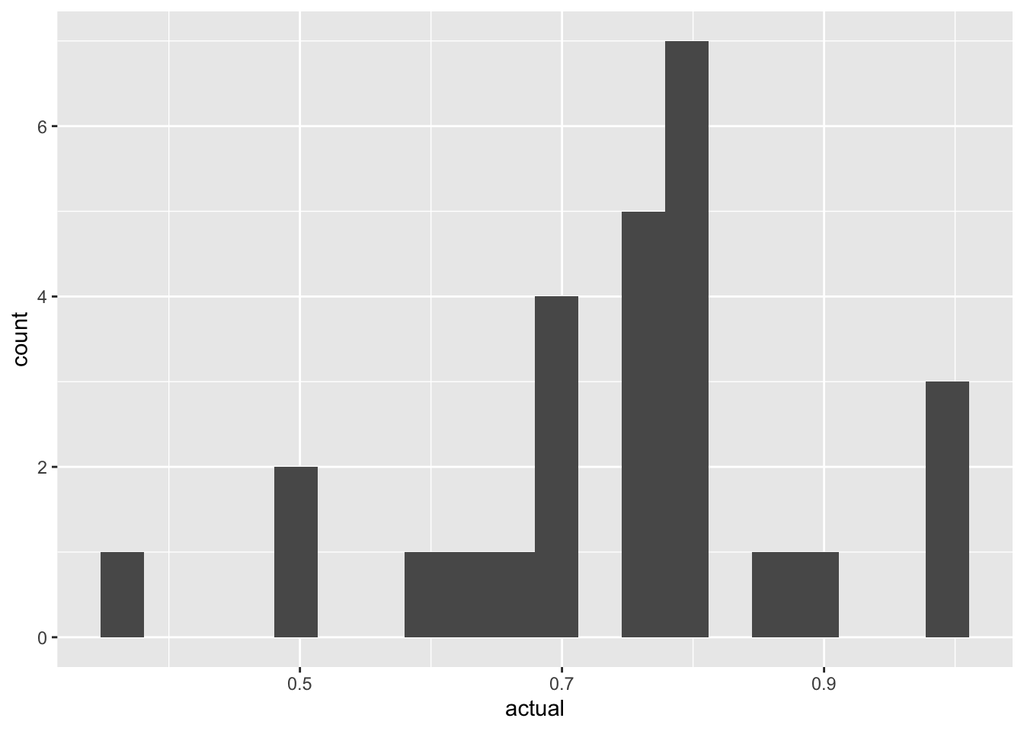

```r
sewing2 |>
  ggplot(aes(x = actual)) +
  geom_histogram(bins = 20)
```

# Model

### 1. Scatterplot matrix

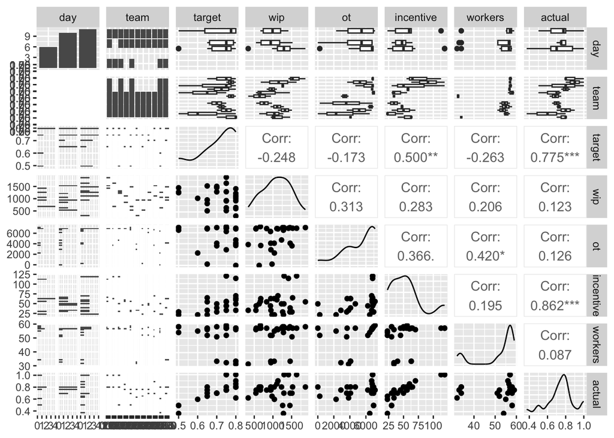

```r
library(GGally)
sewing2 |>  ggpairs()
```

### 2. AIC Variable Selection

```r
n = nrow(sewing2)
mod0 = lm(actual ~ 1, data = sewing2)
mod.all = lm(actual ~., data = sewing2)
step(mod0, scope = list(lower = mod0, upper = mod.all))
```

```
## Start:  AIC=-102.41
## actual ~ 1
##
##             Df Sum of Sq     RSS      AIC
## + incentive  1   0.42011 0.14468 -137.185
## + target     1   0.33904 0.22575 -125.173
## <none>                   0.56479 -102.413
## + ot         1   0.00901 0.55578 -100.847
## + wip        1   0.00854 0.55625 -100.824
## + workers    1   0.00429 0.56051 -100.618
## + day        2   0.00328 0.56151  -98.570
## + team      10   0.21800 0.34679  -95.581
##
## Step:  AIC=-137.19
## actual ~ incentive
##
##             Df Sum of Sq     RSS     AIC
## + target     1   0.08881 0.05586 -160.88
## + ot         1   0.02334 0.12134 -139.94
## + day        2   0.03163 0.11305 -139.85
## <none>                   0.14468 -137.19
## + wip        1   0.00898 0.13569 -136.92
## + workers    1   0.00388 0.14080 -135.92
## + team      10   0.03739 0.10728 -125.26
## - incentive  1   0.42011 0.56479 -102.41
##
## Step:  AIC=-160.88
## actual ~ incentive + target
##
##             Df Sum of Sq      RSS     AIC
## + day        2  0.010323 0.045540 -162.40
## + workers    1  0.005012 0.050852 -161.42
## <none>                   0.055864 -160.88
## + wip        1  0.002600 0.053264 -160.16
## + ot         1  0.000555 0.055309 -159.15
## + team      10  0.016215 0.039649 -150.14
## - target     1  0.088815 0.144678 -137.19
## - incentive  1  0.169885 0.225749 -125.17
##
## Step:  AIC=-162.39
```

[output cut: 22 more lines]

```
## - target     1  0.068447 0.110000 -138.58
## - incentive  1  0.132277 0.173830 -126.23
##
## Step:  AIC=-163.6
## actual ~ incentive + target + day + workers + wip
##
##             Df Sum of Sq      RSS     AIC
## <none>                   0.037555 -163.60
## + ot         1  0.002094 0.035461 -163.15
## - wip        1  0.003998 0.041553 -162.87
## - workers    1  0.004142 0.041697 -162.78
## - day        2  0.010331 0.047887 -161.04
## + team      10  0.009136 0.028419 -151.13
## - target     1  0.069705 0.107260 -137.26
## - incentive  1  0.088863 0.126419 -132.83
```

```
##
## Call:
## lm(formula = actual ~ incentive + target + day + workers + wip,
##     data = sewing2)
##
## Coefficients:
## (Intercept)    incentive       target    dayMonday   dayTuesday      workers
##  -1.226e-01    3.193e-03    7.847e-01    4.061e-02   -3.947e-03    1.548e-03
##         wip
##   4.104e-05
```

```r
mod.full <- lm(formula = actual ~ incentive + target + day + workers + wip,
    data = sewing2)

summary(mod.full)
```

```
##
## Call:
## lm(formula = actual ~ incentive + target + day + workers + wip,
##     data = sewing2)
##
## Residuals:
##       Min        1Q    Median        3Q       Max
## -0.105080 -0.019105 -0.004022  0.024315  0.072704
##
## Coefficients:
##               Estimate Std. Error t value Pr(>|t|)
## (Intercept) -1.226e-01  1.199e-01  -1.022   0.3188
## incentive    3.193e-03  4.642e-04   6.879 1.10e-06 ***
## target       7.847e-01  1.288e-01   6.093 5.91e-06 ***
## dayMonday    4.061e-02  2.326e-02   1.746   0.0961 .
## dayTuesday  -3.947e-03  2.318e-02  -0.170   0.8665
## workers      1.548e-03  1.043e-03   1.485   0.1531
## wip          4.104e-05  2.813e-05   1.459   0.1601
## ---
## Signif. codes:  0 '***' 0.001 '**' 0.01 '*' 0.05 '.' 0.1 ' ' 1
##
## Residual standard error: 0.04333 on 20 degrees of freedom
## Multiple R-squared:  0.9335, Adjusted R-squared:  0.9136
## F-statistic:  46.8 on 6 and 20 DF,  p-value: 9.845e-11
```

### 3. Define a reduced model

```r
mod.reduced <- lm(formula = actual ~ incentive + target + day, data = sewing2 )

summary(mod.reduced)
```

```
##
## Call:
## lm(formula = actual ~ incentive + target + day, data = sewing2)
##
## Residuals:
##       Min        1Q    Median        3Q       Max
## -0.113397 -0.015038 -0.005006  0.026487  0.071588
##
## Coefficients:
##              Estimate Std. Error t value Pr(>|t|)
## (Intercept) 0.0775968  0.0712073   1.090    0.288
## incentive   0.0037342  0.0004009   9.314 4.33e-09 ***
## target      0.6323718  0.1107361   5.711 9.61e-06 ***
## dayMonday   0.0453330  0.0242523   1.869    0.075 .
## dayTuesday  0.0041950  0.0231039   0.182    0.858
## ---
## Signif. codes:  0 '***' 0.001 '**' 0.01 '*' 0.05 '.' 0.1 ' ' 1
##
## Residual standard error: 0.0455 on 22 degrees of freedom
## Multiple R-squared:  0.9194, Adjusted R-squared:  0.9047
## F-statistic: 62.71 on 4 and 22 DF,  p-value: 1.041e-11
```

### 4. anova F test on reduced model

```r
anova(mod.reduced, mod.full)
```

```
## Analysis of Variance Table
##
## Model 1: actual ~ incentive + target + day
## Model 2: actual ~ incentive + target + day + workers + wip
##   Res.Df      RSS Df Sum of Sq      F Pr(>F)
## 1     22 0.045540
## 2     20 0.037555  2 0.0079851 2.1262 0.1455
```

### 5. Define final model

```r
mod = mod.full
summary(mod)
```

```
##
## Call:
## lm(formula = actual ~ incentive + target + day + workers + wip,
##     data = sewing2)
##
## Residuals:
##       Min        1Q    Median        3Q       Max
## -0.105080 -0.019105 -0.004022  0.024315  0.072704
##
## Coefficients:
##               Estimate Std. Error t value Pr(>|t|)
## (Intercept) -1.226e-01  1.199e-01  -1.022   0.3188
## incentive    3.193e-03  4.642e-04   6.879 1.10e-06 ***
## target       7.847e-01  1.288e-01   6.093 5.91e-06 ***
## dayMonday    4.061e-02  2.326e-02   1.746   0.0961 .
## dayTuesday  -3.947e-03  2.318e-02  -0.170   0.8665
## workers      1.548e-03  1.043e-03   1.485   0.1531
## wip          4.104e-05  2.813e-05   1.459   0.1601
## ---
## Signif. codes:  0 '***' 0.001 '**' 0.01 '*' 0.05 '.' 0.1 ' ' 1
##
## Residual standard error: 0.04333 on 20 degrees of freedom
## Multiple R-squared:  0.9335, Adjusted R-squared:  0.9136
## F-statistic:  46.8 on 6 and 20 DF,  p-value: 9.845e-11
```

### 6. Check LINE conditions on final model

Final model is: lm(formula = actual ~ incentive + target + day + workers + wip, data = sewing2)

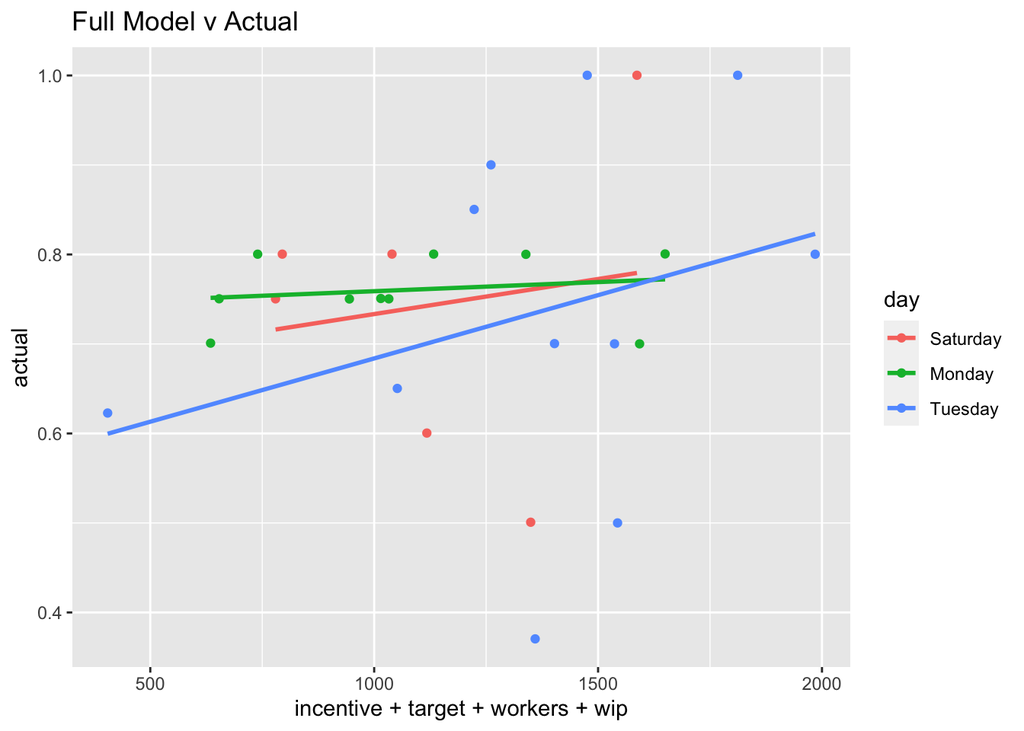

```r
sewing2 |>
  ggplot(aes(x = incentive + target + workers + wip, y = actual, color = day)) +
  geom_point() + geom_smooth(method = "lm", se=FALSE) +
  ggtitle("Full Model v Actual")
```

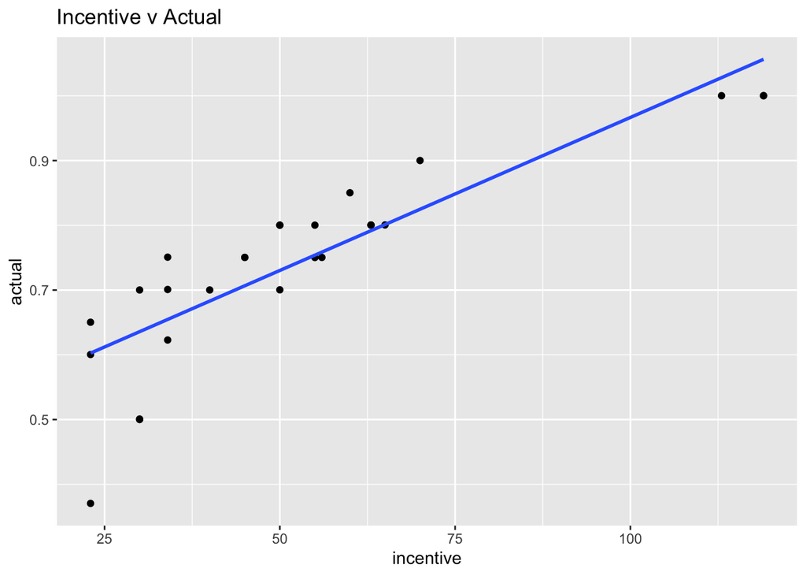

```r
sewing2 |>
  ggplot(aes(x = incentive, y = actual)) +
  geom_point() + geom_smooth(method = "lm", se=FALSE) +
  ggtitle("Incentive v Actual")
```

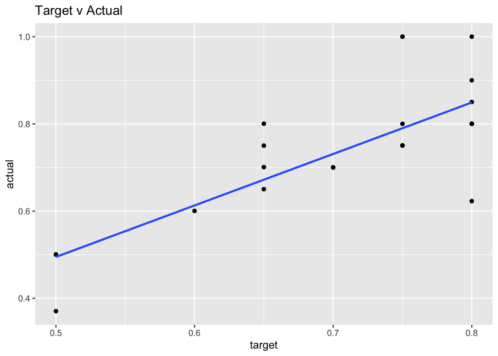

```r
sewing2 |>
  ggplot(aes(x = target, y = actual)) +
  geom_point() + geom_smooth(method = "lm", se=FALSE) +
  ggtitle("Target v Actual")
```

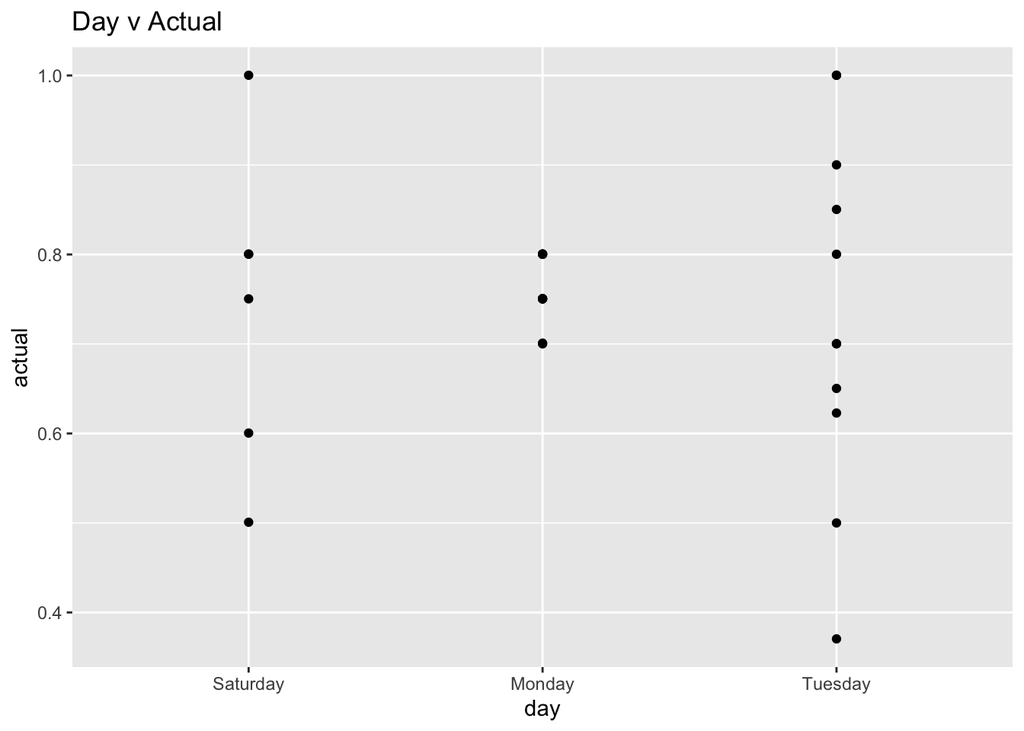

```r
sewing2 |>
  ggplot(aes(x = day, y = actual)) +
  geom_point() + geom_smooth(method = "lm", se=FALSE) +
  ggtitle("Day v Actual")
```

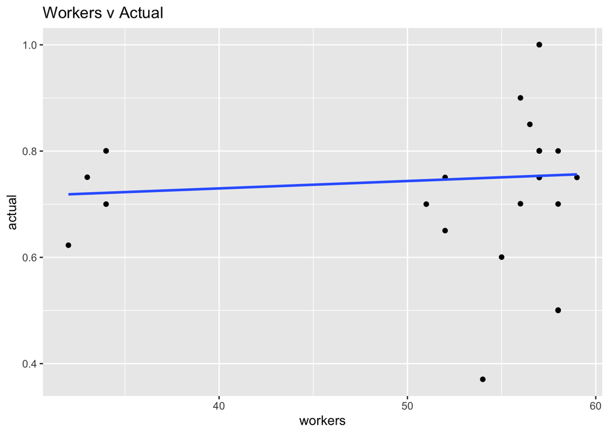

```r
sewing2 |>
  ggplot(aes(x = workers, y = actual)) +
  geom_point() + geom_smooth(method = "lm", se=FALSE) +
  ggtitle("Workers v Actual")
```

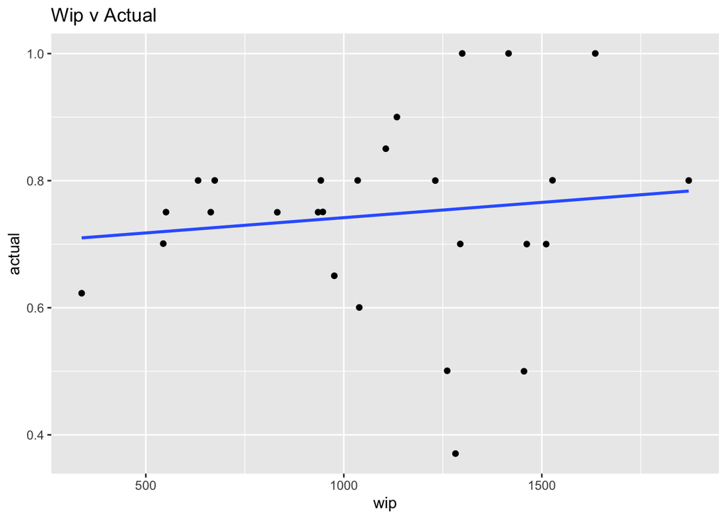

```r
sewing2 |>
  ggplot(aes(x = wip, y = actual)) +
  geom_point() + geom_smooth(method = "lm", se=FALSE) +
  ggtitle("Wip v Actual")
```

```r
library(broom)
model.table = augment(mod)
names(model.table)
```

```
##  [1] "actual"     "incentive"  "target"     "day"        "workers"
##  [6] "wip"        ".fitted"    ".resid"     ".hat"       ".sigma"
## [11] ".cooksd"    ".std.resid"
```

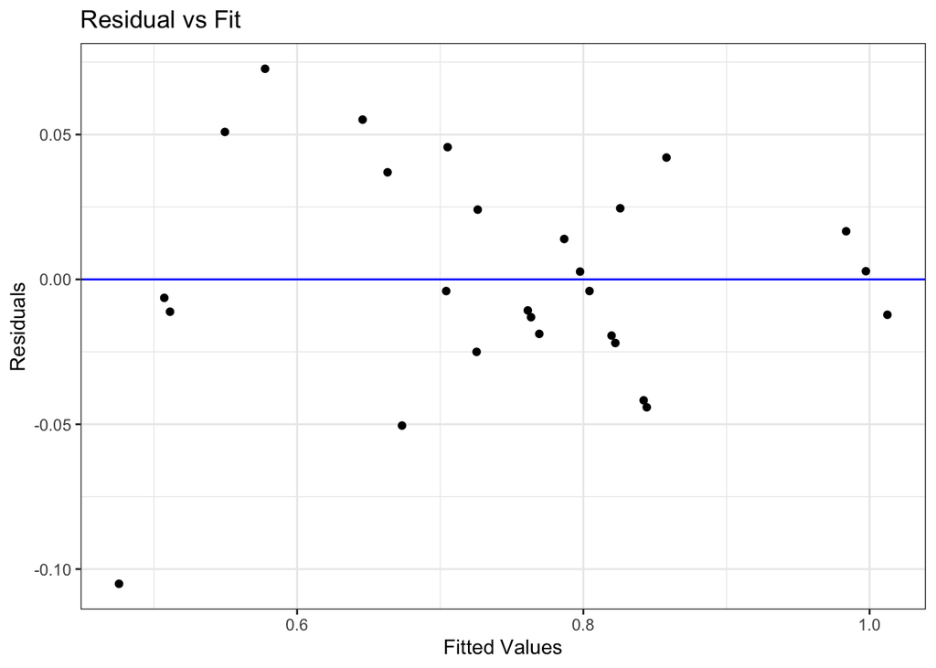

```r
ggplot(model.table, aes(x = .fitted, y = .resid)) +
  geom_point() +
  geom_hline(yintercept = 0, colour = 'blue') +
  labs(x = 'Fitted Values', y = 'Residuals') +
  ggtitle('Residual vs Fit') +
  theme_bw()
```

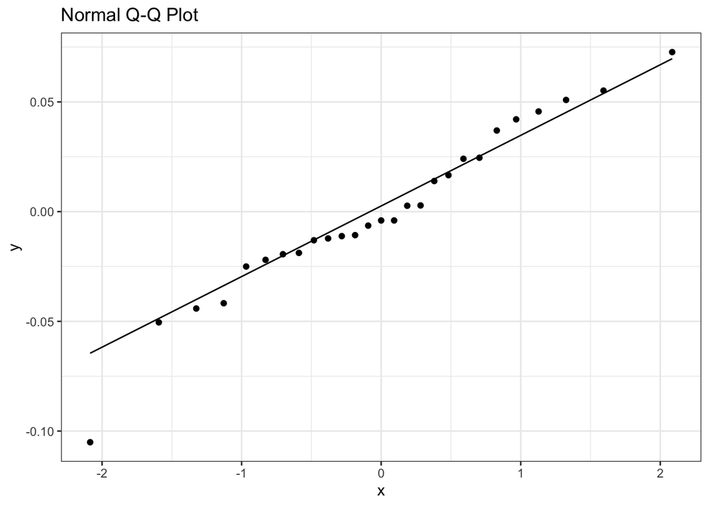

```r
ggplot(model.table, aes(sample = .resid)) +
  stat_qq() +
  stat_qq_line() +
  ggtitle('Normal Q-Q Plot') +
  theme_bw()
```

```r
shapiro.test(resid(mod))
```

```
##
##  Shapiro-Wilk normality test
##
## data:  resid(mod)
## W = 0.9667, p-value = 0.5175
```